# R cheatsheet

Created by: Emily Harders and Andrew Kraemer

Last edited: 8 February 2022

# READING IN DATA

### read.csv()

The `read.csv` function takes a csv file from your computer and uploads it into R

```r
bumpusdata<-read.csv("BIO311_data_bumpus.csv")
```

### rm(list=ls())

`rm(list=ls())` clears R’s memory, clearing anything you have named, or any other code you have run.

### getwd()

The `getwd()` function will tell you what working directory is running in R. Great for trouble-shooting

### setwd()

On a Mac, I prefer to use command+D to set the working directory, but this code works if your computer is being stubborn or you need to change your working directory for a specific section

```r
setwd("~/Desktop/Biostats/Files")
```

# MATRIX MANIPULATION

### matrix(c( )nrow= )

The `matrix(c( ), nrow= )` function is used to create a matrix within the c() function list the numbers down the columns of the matrix

```r
a<-matrix(c(1,2,3,4,5,6,7,8,9,10,11,12,13,14), nrow=2)
a
```

```
##      [,1] [,2] [,3] [,4] [,5] [,6] [,7]
## [1,]    1    3    5    7    9   11   13
## [2,]    2    4    6    8   10   12   14
```

### t()

The `t()` function transposes the matrix, so column 1 -> row 1, column 2 -> row 2, column 3 -> row 3, etc. in the transposed matrix.

Before transpose

```r
b<-matrix(c(2,4,6,8,10,12,14,16,18,20,22,24,26,28), nrow=2)
b
```

```
##      [,1] [,2] [,3] [,4] [,5] [,6] [,7]
## [1,]    2    6   10   14   18   22   26
## [2,]    4    8   12   16   20   24   28
```

After transpose

```r
tb<-t(b)
tb
```

```
##      [,1] [,2]
## [1,]    2    4
## [2,]    6    8
## [3,]   10   12
## [4,]   14   16
## [5,]   18   20
## [6,]   22   24
## [7,]   26   28
```

### cbind()

The function `cbind()` allows you to add two matrices together by the columns (pushing matrices together side-by-side)

```r
cbind(a,b)
```

```
##      [,1] [,2] [,3] [,4] [,5] [,6] [,7] [,8] [,9] [,10] [,11] [,12] [,13] [,14]
## [1,]    1    3    5    7    9   11   13    2    6    10    14    18    22    26
## [2,]    2    4    6    8   10   12   14    4    8    12    16    20    24    28
```

### rbind()

The function `rbind()` allows you to add two matrices together by the rows. (stacking matrices on top of each other)

```r
rbind(a,b)
```

```
##      [,1] [,2] [,3] [,4] [,5] [,6] [,7]
## [1,]    1    3    5    7    9   11   13
## [2,]    2    4    6    8   10   12   14
## [3,]    2    6   10   14   18   22   26
## [4,]    4    8   12   16   20   24   28
```

### is.matrix

`is.matrix` function “asks” R if it is understanding an object/list as a matrix.

- An output of TRUE means that the object is being read as a matrix
- An output of FALSE means that the object is being NOT read as a matrix

```r
is.matrix(a)
```

```
## [1] TRUE
```

### as.matrix

`as.matrix` function “commands” R to understanding an object/list as a matrix, even if it is not supposed to be a matrix.

Originally, “not_M” is not being read as a matrix

```r
not_M<-c(1,2,3,4,5,6,7,8,9,1,0,11,12)
is.matrix(not_M)
```

```
## [1] FALSE
```

…but after using as.matrix, not_M is being read as a matrix.

```r
new_not_M<-as.matrix(not_M)
is.matrix(new_not_M)
```

```
## [1] TRUE
```

### %*%

The `%*%` function multiplies two matrices together

```r
a%*%tb
```

```
##      [,1] [,2]
## [1,]  910 1008
## [2,] 1008 1120
```

# MANIPULATING DATA

### $

The `$` isn’t a function, but it is very useful because it allows you to isolate a column from a matrix.

```r
bumpusdata$sex
```

```
##   [1] "male"   "male"   "male"   "male"   "male"   "male"   "male"   "male"
##   [9] "male"   "male"   "male"   "male"   "male"   "male"   "male"   "male"
##  [17] "male"   "male"   "male"   "male"   "male"   "male"   "male"   "male"
##  [25] "male"   "male"   "male"   "male"   "male"   "male"   "male"   "male"
##  [33] "male"   "male"   "male"   "male"   "male"   "male"   "male"   "male"
##  [41] "male"   "male"   "male"   "male"   "male"   "male"   "male"   "male"
##  [49] "male"   "male"   "male"   "male"   "male"   "male"   "male"   "male"
##  [57] "male"   "male"   "male"   "male"   "male"   "male"   "male"   "male"
##  [65] "male"   "male"   "male"   "male"   "male"   "male"   "male"   "male"
##  [73] "male"   "male"   "male"   "male"   "male"   "male"   "male"   "male"
##  [81] "male"   "male"   "male"   "male"   "male"   "male"   "male"   "female"
##  [89] "female" "female" "female" "female" "female" "female" "female" "female"
##  [97] "female" "female" "female" "female" "female" "female" "female" "female"
## [105] "female" "female" "female" "female" "female" "female" "female" "female"
## [113] "female" "female" "female" "female" "female" "female" "female" "female"
## [121] "female" "female" "female" "female" "female" "female" "female" "female"
## [129] "female" "female" "female" "female" "female" "female" "female" "female"
```

```r
bumpusdata$wgt
```

```
##   [1] 24.5 26.9 26.9 24.3 24.1 26.5 24.6 24.2 23.6 26.2 26.2 24.8 25.4 23.7 25.7
##  [16] 25.7 26.5 26.7 23.9 24.7 28.0 27.9 25.9 25.7 26.6 23.2 25.7 26.3 24.3 26.7
##  [31] 24.9 23.8 25.6 27.0 24.7 26.5 26.1 25.6 25.9 25.5 27.6 25.8 24.9 26.0 26.5
##  [46] 26.0 27.1 25.1 26.0 25.6 25.0 24.6 25.0 26.0 28.3 24.6 27.5 31.0 28.3 24.6
##  [61] 25.5 24.8 26.3 24.4 23.3 26.7 26.4 26.9 24.3 27.0 26.8 24.9 26.1 26.6 23.3
##  [76] 24.2 26.8 23.5 26.9 28.6 24.7 27.3 25.7 29.0 25.0 27.5 26.0 25.3 22.6 25.1
##  [91] 23.2 24.4 25.1 24.6 24.0 24.2 24.9 24.1 24.0 26.0 24.9 25.5 23.4 25.9 24.2
## [106] 24.2 27.4 24.0 26.3 25.8 26.0 23.2 26.5 24.2 26.9 27.7 23.9 26.1 24.6 23.6
## [121] 26.0 25.0 24.8 22.8 24.8 24.6 30.5 24.8 23.9 24.7 26.9 22.6 26.1 24.8 26.2
## [136] 26.1
```

### subset()

The `subset()` function allows you to create a more specific matrix from a larger one, based on one variable. For example, the “males” subset below, sifts through “bumpusdata” and picks out all the individuals whose sex is male.

```r
males<-subset(bumpusdata, bumpusdata$sex=="male")
```

### head()

The `head()` function lets you see the title of each column and the first 6 rows of the datasheet

```r
head(males)
```

```
##    sex  surv totlen wingext  wgt head humer femur tibio skull stern ln.totlen.
## 1 male alive    154     241 24.5 31.2 0.687 0.668 1.022 0.587 0.830   5.036953
## 2 male alive    160     252 26.9 30.8 0.736 0.709 1.180 0.602 0.841   5.075174
## 3 male alive    155     243 26.9 30.6 0.733 0.704 1.151 0.602 0.846   5.043425
## 4 male alive    154     245 24.3 31.7 0.741 0.688 1.146 0.584 0.839   5.036953
## 5 male alive    156     247 24.1 31.5 0.715 0.706 1.129 0.575 0.821   5.049856
## 6 male alive    161     253 26.5 31.8 0.780 0.743 1.144 0.607 0.893   5.081404
##   ln.wingext.  ln.wgt. ln.head.  ln.humer.  ln.femur.  ln.tibio.  ln.skull.
## 1    5.484797 1.066224 3.440418 -0.3754210 -0.4034671 0.02176149 -0.5327305
## 2    5.529429 1.097375 3.427515 -0.3065252 -0.3438998 0.16551444 -0.5074978
## 3    5.493061 1.097375 3.421000 -0.3106096 -0.3509769 0.14063113 -0.5074978
## 4    5.501258 1.063492 3.456317 -0.2997547 -0.3739664 0.13627762 -0.5378543
## 5    5.509388 1.060737 3.449988 -0.3354727 -0.3481400 0.12133229 -0.5533852
## 6    5.533389 1.092382 3.459466 -0.2484614 -0.2970592 0.13453089 -0.4992265
##    ln.stern.
## 1 -0.1863296
## 2 -0.1731636
## 3 -0.1672359
## 4 -0.1755446
## 5 -0.1972322
## 6 -0.1131687
```

### length()

The `length()` function finds the length of a vector. Uou have to specify a column, because if you include an entire matrix (with rows **and** columns) within the argument R will only count the number of columns.

- You have to pair males, with survival (or any other column in bumpusdata), otherwise R will count horizontally (the number of coumns), instead of counting the number of rows.
  - There are 87 males

```r
length(males$surv)
```

```
## [1] 87
```

### summary()

The `summary()`function allows you to view descritive statistics from your dataset.

```r
summary(males$wgt)
```

```
##    Min. 1st Qu.  Median    Mean 3rd Qu.    Max.
##    23.2    24.7    25.8    25.8    26.7    31.0
```

### c()

The `c()` function allows you to link together a string of individual (numbers, colors, labels, etc.) to create a vector

- When creating a vector with words, you need to put each word into quotations.

```r
age<-c(11,14,12,9,11,16,8,10,13,6,5)
names<-c("Sally","Mark","Jeff", "Bill", "Sarah", "Sam", "Karen", "Krista", "Amy", "Mathew", "Caroline")
```

```r
age
```

```
##  [1] 11 14 12  9 11 16  8 10 13  6  5
```

```r
names
```

```
##  [1] "Sally"    "Mark"     "Jeff"     "Bill"     "Sarah"    "Sam"
##  [7] "Karen"    "Krista"   "Amy"      "Mathew"   "Caroline"
```

### paste()

The `paste()` function takes two identifying factors of an individual, and combines them together into one identifying factor.

```r
class<-paste(age,names)
class
```

```
##  [1] "11 Sally"   "14 Mark"    "12 Jeff"    "9 Bill"     "11 Sarah"
##  [6] "16 Sam"     "8 Karen"    "10 Krista"  "13 Amy"     "6 Mathew"
## [11] "5 Caroline"
```

### rep()

The `rep()` function repeats a specific number or word as a vector a specific number of times.

- This function repeats the word “RED”, “BLUE”, and “YELLOW” 25 times each.

```r
c(rep("RED",25), rep("BLUE",25), rep("YELLOW", 25))
```

```
##  [1] "RED"    "RED"    "RED"    "RED"    "RED"    "RED"    "RED"    "RED"
##  [9] "RED"    "RED"    "RED"    "RED"    "RED"    "RED"    "RED"    "RED"
## [17] "RED"    "RED"    "RED"    "RED"    "RED"    "RED"    "RED"    "RED"
## [25] "RED"    "BLUE"   "BLUE"   "BLUE"   "BLUE"   "BLUE"   "BLUE"   "BLUE"
## [33] "BLUE"   "BLUE"   "BLUE"   "BLUE"   "BLUE"   "BLUE"   "BLUE"   "BLUE"
## [41] "BLUE"   "BLUE"   "BLUE"   "BLUE"   "BLUE"   "BLUE"   "BLUE"   "BLUE"
## [49] "BLUE"   "BLUE"   "YELLOW" "YELLOW" "YELLOW" "YELLOW" "YELLOW" "YELLOW"
## [57] "YELLOW" "YELLOW" "YELLOW" "YELLOW" "YELLOW" "YELLOW" "YELLOW" "YELLOW"
## [65] "YELLOW" "YELLOW" "YELLOW" "YELLOW" "YELLOW" "YELLOW" "YELLOW" "YELLOW"
## [73] "YELLOW" "YELLOW" "YELLOW"
```

### which()

The `which()` function will tell you the position of numbers in a vector that satisfy a certain condition

- Say we have 9 children in a single file line. The first child is 12 years old, the second is 11 years old, etc. Each child has a specific spot in relation to the other children. Using the which() function I can find the position of children over the age of 10. There are 6 children that are over the age of 10

`which(vector,condition,value)`

```r
children<-c(12,11,13,18,9,11,7,5,15)
which(children>=10)
```

```
## [1] 1 2 3 4 6 9
```

By combining the which() and length() functions I can find the total number of children that are over (or under using <=) the age of 10.

```r
length(which(children>=10))
```

```
## [1] 6
```

### set.seed() and rnorm()

`set.seed` is R’s random number generator, this is useful for creating simulations or random objects that can be **reproduced** `rnorm()` generates a vector of normally distributed random numbers.

- by combining set.seed() and rnorm(), you can create unique set of normally distrubued numbers.
  - The semicolon allows you to perform two “lines of code” on a single line. It is important not to overuse this function, it is much easier to stay organized in R when using seperate lines for seperate functions.

Below is simulated data showing the ages of residents in two retirement homes

```r
set.seed(12345); retire1_data<-rnorm(n=1000,mean=90, sd=3.3)
set.seed(54321); retire2_data<-rnorm(n=1000,mean=86, sd=5.1)
```

### tapply()

Using the `tapply()` function requires continuous data,the categories and the calculation you want to do. tapply(continuous, categories, function)

Using the simulated data for ages of residents in two retirement homes, we can find the mean of the two goups using the tapply function

```r
retirement_ages<-c(retire1_data, retire2_data)
groups<-c(rep("retire1",1000), rep("retire2",1000))
tapply(retirement_ages, groups, mean)
```

```
##  retire1  retire2
## 90.15245 85.69500
```

### sample()

the `sample()` function can take a sample from a data set. In this case we have a bowl with 15 red marbles and 20 blue marbles

sample(dataset, number of individuals in each sample)

```r
bowl<-c(rep("RED", 15), rep("BLUE", 20))
sample(bowl, 5)
```

```
## [1] "BLUE" "BLUE" "BLUE" "RED"  "BLUE"
```

### loops

Here is the general “formula” for loops

**output<-NULL**  
**n<- #number of times the loop runs**  
**for(i in 1:n){**  
**#tasks…enter code you want to run repeatedly**  
**output<-c(output, task result) #this line puts the outputs in a list**  
**}**

For example, say I have a bowl of 500 seeds with an average mass of 50 mg. What is the probability that if I sample 2 seeds from the bowl, the average will be greater than 50?

```r
set.seed(2); seeds<-rnorm(n=500,mean=50,sd=10)
safe<-NULL
n<-100
for(i in 1:n){
  two_seeds<-sample(seeds, 2)
  avg.seed.wgt<-mean(two_seeds)
  safe<-c(safe, avg.seed.wgt)
}

safe
```

```
##   [1] 43.97922 36.90870 44.93668 49.91626 40.96983 55.82035 46.43654 37.94947
##   [9] 49.47774 50.22644 47.03734 48.81078 48.14952 47.59182 40.70522 42.03103
##  [17] 45.76630 55.70223 45.88820 53.69483 54.12571 57.03809 51.07268 58.68751
##  [25] 39.83478 46.19148 51.83130 63.84573 55.51624 49.52302 51.41520 47.70737
##  [33] 52.27610 51.52731 43.00705 52.95428 44.34729 40.20665 49.02499 41.93531
##  [41] 45.59049 52.39999 43.79383 48.61107 47.78200 50.12925 56.58457 48.65879
##  [49] 44.79310 37.00825 49.11025 49.44308 48.82775 56.64500 48.51056 56.35618
##  [57] 58.19276 47.47752 44.43717 46.01646 49.68217 45.69071 51.60491 57.60865
##  [65] 53.81550 60.15821 52.07288 51.56725 36.49347 60.44048 54.43019 49.77132
##  [73] 51.94806 62.16748 46.79578 58.81680 42.65649 54.80501 48.81661 49.65638
##  [81] 49.53910 53.70813 55.22174 57.37680 58.64993 37.35117 53.26432 47.25255
##  [89] 51.53240 58.14221 45.38624 39.30462 49.33671 53.51132 58.88295 58.40648
##  [97] 51.88707 42.09528 44.99873 54.44381
```

```r
#Outside the loop, you can figure out the probability of pair of seeds being over 50 milligrams

sum(safe>=50)/n
```

```
## [1] 0.45
```

### table()

The `table()` function builds a contingency table of the counts for each combination of categorical factors

```r
bumpustable<-table(bumpusdata$sex, bumpusdata$surv)
bumpustable
```

```
##
##          alive dead
##   female    21   28
##   male      51   36
```

# TESTING ASSUMPTIONS

## Normality

### qqnorm()

The `qqrnorm()` is a normality visualization that creates a scatter plot of your data vector against expected values of data if they were *normally distributed* about the mean. If the data is normally distributed, the data will be in a straight linear line.

For example, the male bird weight from the bumpus data. (the “males” subset was made previously)

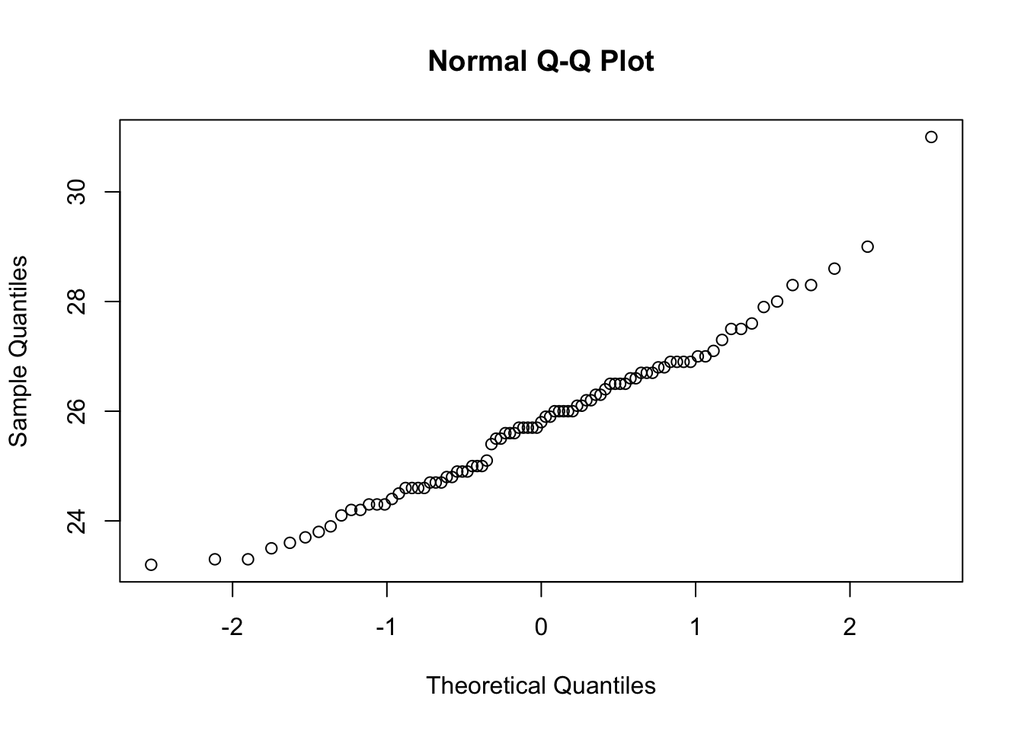

```r
qqnorm(males$wgt)
```

### shapiro.test()

The Shapiro-Wilk tests if a data vector is normally distributed. If the test is significant, then the data do NOT come from a normally distributed population. Remember this by thinking that the data is “significantly different from a normal population”

For example, the male bird weight from the bumpus data.

```r
shapiro.test(males$wgt)
```

```
##
##  Shapiro-Wilk normality test
##
## data:  males$wgt
## W = 0.97221, p-value = 0.05782
```

## Equal variance

### var.test()

When the data are normal, the F-test compares the variances of 2 groups. If the test is significant, the variances of the two groups are NOT equal. Remember this by thinking that the data is “significantly different from having equal variance.” The F-test can only compare two groups.

For example, the male and female bird weight from the bumpus data.

```r
var.test(males$wgt,females$wgt)
```

```
##
##  F test to compare two variances
##
## data:  males$wgt and females$wgt
## F = 0.95272, num df = 86, denom df = 48, p-value = 0.8306
## alternative hypothesis: true ratio of variances is not equal to 1
## 95 percent confidence interval:
##  0.5649791 1.5491011
## sample estimates:
## ratio of variances
##           0.952718
```

The test is NOT signfificant, so the two data sets have equal variance.

### leveneTest()

When the data are NOT normal, the levene test compares the variances between 2+ groups. If the test is significant, the variances of the groups are NOT equal

To use the levene test, you have to first, download the package “car”.

```r
# install.packages('car')
library(car)
```

For example, the male weight (y) and male survival (x) from the bumpus data.

```r
leveneTest(males$wgt~males$surv)
```

```
## Levene's Test for Homogeneity of Variance (center = median)
##       Df F value Pr(>F)
## group  1  0.0591 0.8085
##       85
```

The result from the levene test is not significant so the groups (male alive and male dead) have equal variances.

# INFERENTIAL STATISTICS

### dbinom()

`dbinom(x, size, prob)` **x= a vector of numbers, size=number of trials, prob= probability of success for each trial**  
Using a bionomial probability distribution, you can use the dbinom() function to calculate the probability of exactly one outcome under that null distribution.

- Returning to our simulated retirement home data, I want to know if I knock on 20 doors in the retirement home, what are the chances that exactly 5 95-year-olds will answer their door (The probability of success i.e. finding a 95-year-old is 0.055)?

```r
dbinom(5,20, 0.055)
```

```
## [1] 0.003339907
```

### binom.test()

`binom.test(number of sucesses, number of trials)`  
p=expected/hypothesized probability of success, alternative=“two.sided” “greater” or “less”)**

You can use binom.test() function to calculate the probability of success under a binomial probability distribution. Where dbinom() only calculates the probability of one specific outcome/sucess, binom.test() calculates a range of outcomes that are all considered a success.

- Again returning to the retirement home data, if I knock on 20 doors in the retirement home, what are the chances that I will find five people who are 95-years-old OR OLDER will answer their door (The probability of success i.e. finding a 95-year-old is 0.061)?

```r
binom.test(5, 20, p=0.061, alternative="greater")
```

```
##
##
##
## data:  5 out of 20
## number of successes = 5, number of trials = 20, p-value = 0.006041
## alternative hypothesis: true probability of success is greater than 0.061
## 95 percent confidence interval:
##  0.1040808 1.0000000
## sample estimates:
## probability of success
##                   0.25
```

### chisq.test()

`chisq.test(x, p=)` is a chi-squared goodness-of-fit test (where x is data and p is null probability)

- An example of this the different amounts of each color of skittle in the bag. (blue=103, red=61, green=55, orange=64, yellow=77)

```r
chisq.test(c(103,61,55,64,77), p=c(0.2,0.2,0.2,0.2,0.2))
```

```
##
##  Chi-squared test for given probabilities
##
## data:  c(103, 61, 55, 64, 77)
## X-squared = 20.278, df = 4, p-value = 0.0004401
```

chisq.test(x) is a chi-squared test-of-association (where x is the data)

- Looking back to the bumpus data, did sex of the bird influence if it lived or died? We can answer this using a chi-squared test-of-association. (The expected probability is derived from the observed data, so thats why its not in the function)

```r
bumpustable<-table(bumpusdata$sex, bumpusdata$surv)
chisq.test(bumpustable)
```

```
##
##  Pearson's Chi-squared test with Yates' continuity correction
##
## data:  bumpustable
## X-squared = 2.5257, df = 1, p-value = 0.112
```

### t.test()

Unsurprisingly, the function, t.test is used to perform a t-test on a dataset. A t-test can determine if there is a significant difference between the means of two goups (with continuous data).

There are 3 different types of t-tests:

**One-sample t-test** Also called the “Goodness of Fit t-test.” How the population mean compares to some hypothesized value. Example: Imagine we want to compare this years flow of the Nile river compared to the average flow over the last 20 years (800.53)  
(The dataset Nile is pre-loaded into R)

[output not shown]

Based on this one-sample t.test, there is a significant difference between the mean flow of the Nile river this year, to the mean over the last 20 years.

**Two-sample t-test** How the means of two groups are different. For example, if we want to see if there is a significant difference in the weight’s of crickets after feeding them either food-x or food-y

- (The dataset randu is pre-loaded into R)

```r
t.test(randu$x,randu$y)
```

```
##
##  Welch Two Sample t-test
##
## data:  randu$x and randu$y
## t = 1.9731, df = 797.28, p-value = 0.04883
## alternative hypothesis: true difference in means is not equal to 0
## 95 percent confidence interval:
##  0.0002075138 0.0805449562
## sample estimates:
## mean of x mean of y
## 0.5264293 0.4860531
```

Based on this two-sample t.test, there is a significant difference between the weights of the crickets under the two different food groups.

**Paired t-test** Determines whether the mean of two different groups is 0 (null hypothesis) or not (alternative). For example, the number of pimples before and after a cream is applied from a dermatologiest.

```r
set.seed(4); before_cream<-rnorm(10, mean=10, sd=6 )
set.seed(4); after_cream<-rnorm(10, mean=9, sd=7)
t.test(before_cream, after_cream, paired=TRUE)
```

```
##
##  Paired t-test
##
## data:  before_cream and after_cream
## t = 1.3088, df = 9, p-value = 0.223
## alternative hypothesis: true difference in means is not equal to 0
## 95 percent confidence interval:
##  -0.3157605  1.1827019
## sample estimates:
## mean of the differences
##               0.4334707
```

Based on this paired t.test, there is NO significant difference between the number of pimples before and after the cream. Maybe time to find a new dermatologist…

### summary(aov())

The `summary(aov())` function above us used to conduct and ANOVA (Analysis of Variance) which is a test that uses the difference in variation to see if the mean between groups are different

- Unlike the two-sample t.test, you can have more than two groups
- For example, determing if plants have different CO2 intake based on their type (Quebec or Mississippi) AND treatment (chilled or nonchilled)
- **IMPORTANT- ANOVA’s do NOT tell you WHICH of the groups are different, only that a difference exists between at least two of the groups.**
  - CO2 is a preloaded dataset in R

```r
PLANT<-paste(CO2$Type, CO2$Treatment)
summary(aov(CO2$uptake~PLANT))
```

```
##             Df Sum Sq Mean Sq F value   Pr(>F)
## PLANT        3   4579  1526.5   23.82 4.11e-11 ***
## Residuals   80   5128    64.1
## ---
## Signif. codes:  0 '***' 0.001 '**' 0.01 '*' 0.05 '.' 0.1 ' ' 1
```

### TukeyHSD(aov())

A **Tukey test** must be used to identify the groups that have a significant difference. The output is a list of p-values of the differences between each of the pairings.

```r
TukeyHSD(aov(CO2$uptake~PLANT))
```

```
##   Tukey multiple comparisons of means
##     95% family-wise confidence level
##
## Fit: aov(formula = CO2$uptake ~ PLANT)
##
## $PLANT
##                                                 diff        lwr      upr
## Mississippi nonchilled-Mississippi chilled 10.138095  3.6553560 16.62083
## Quebec chilled-Mississippi chilled         15.938095  9.4553560 22.42083
## Quebec nonchilled-Mississippi chilled      19.519048 13.0363083 26.00179
## Quebec chilled-Mississippi nonchilled       5.800000 -0.6827393 12.28274
## Quebec nonchilled-Mississippi nonchilled    9.380952  2.8982131 15.86369
## Quebec nonchilled-Quebec chilled            3.580952 -2.9017869 10.06369
##                                                p adj
## Mississippi nonchilled-Mississippi chilled 0.0005553
## Quebec chilled-Mississippi chilled         0.0000000
## Quebec nonchilled-Mississippi chilled      0.0000000
## Quebec chilled-Mississippi nonchilled      0.0959830
## Quebec nonchilled-Mississippi nonchilled   0.0015893
## Quebec nonchilled-Quebec chilled           0.4727714
```

# PLOTTING DATA

### hist()

The `hist()` function creates a histogram of the weight of male birds.

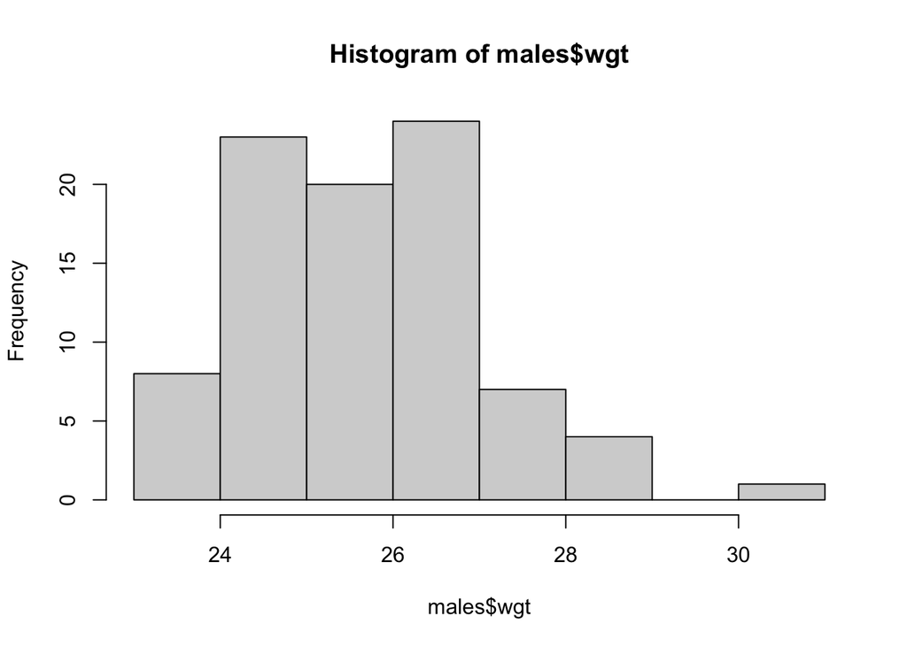

```r
hist(males$wgt)
```

### boxplot()

Creates a boxplot of bird weight and “male alive” “male dead” “female alive” “female dead”

- The generic formula for a boxplot is `boxplot(y~x)`
  - y= continuous
  - x= categorical

Notice the paste function!

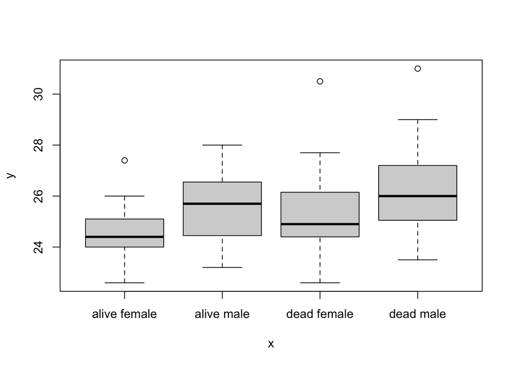

```r
y<-bumpusdata$wgt
x<-paste(bumpusdata$surv,bumpusdata$sex)
boxplot(y~x)
```

### barplot()

Plot with a categorical and continuous variables

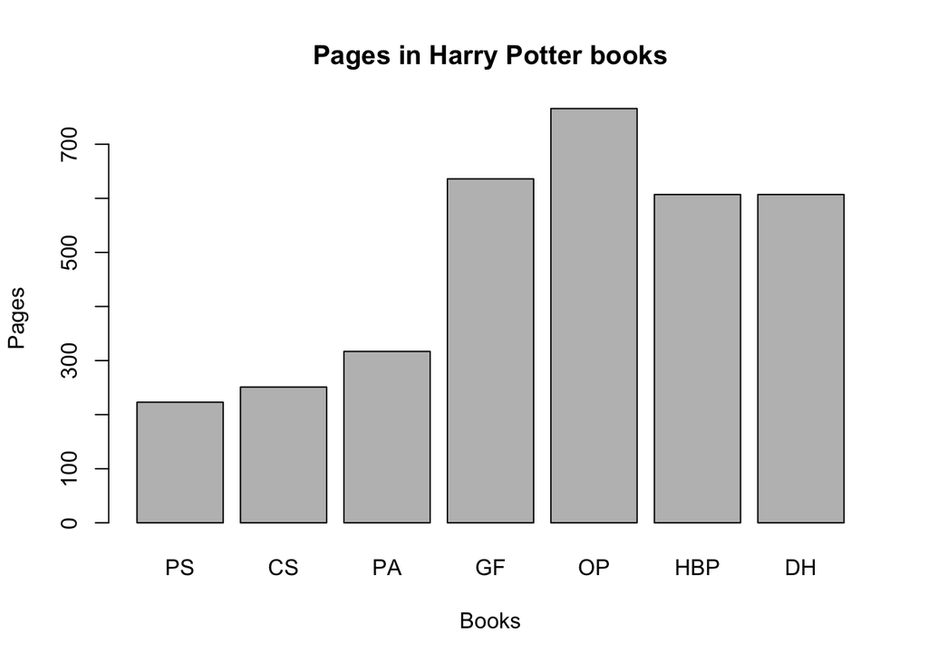

```r
barplot(c(223,251,317,636,766,607,607), main="Pages in Harry Potter books", ylab="Pages", xlab="Books", names=c("PS","CS","PA","GF","OP","HBP","DH"))
```

# PLOT MODIFIERS

### main=

The `main=` modifier titles the plot

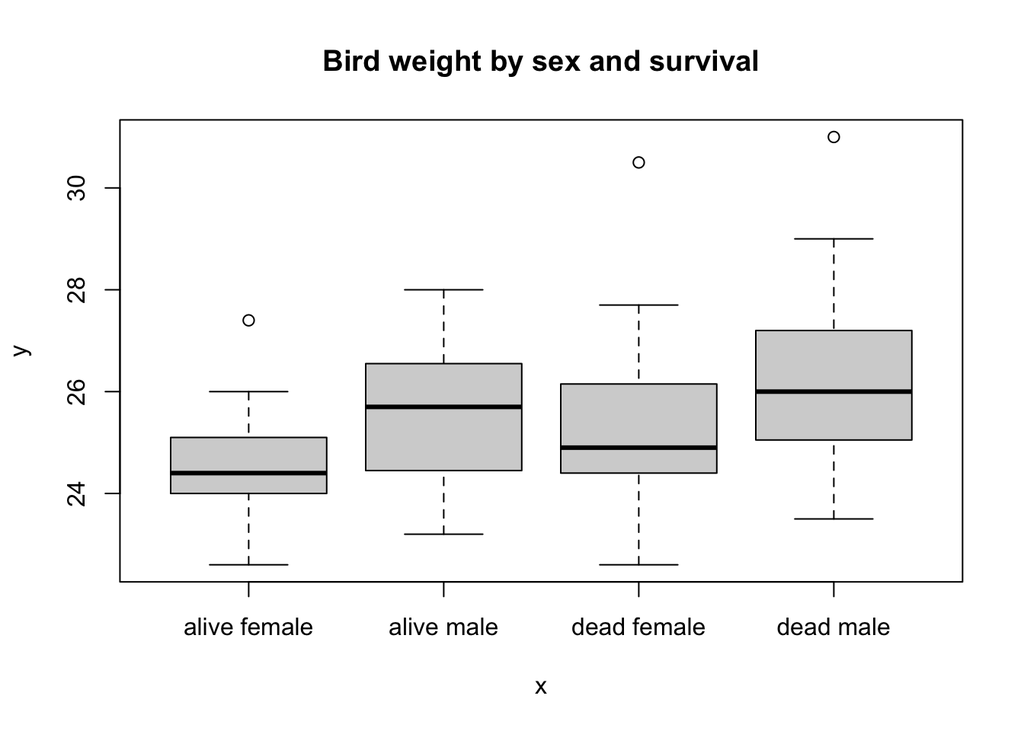

```r
boxplot(y~x, main="Bird weight by sex and survival")
```

### ylab=

The `ylab` modifier labels the y-axis

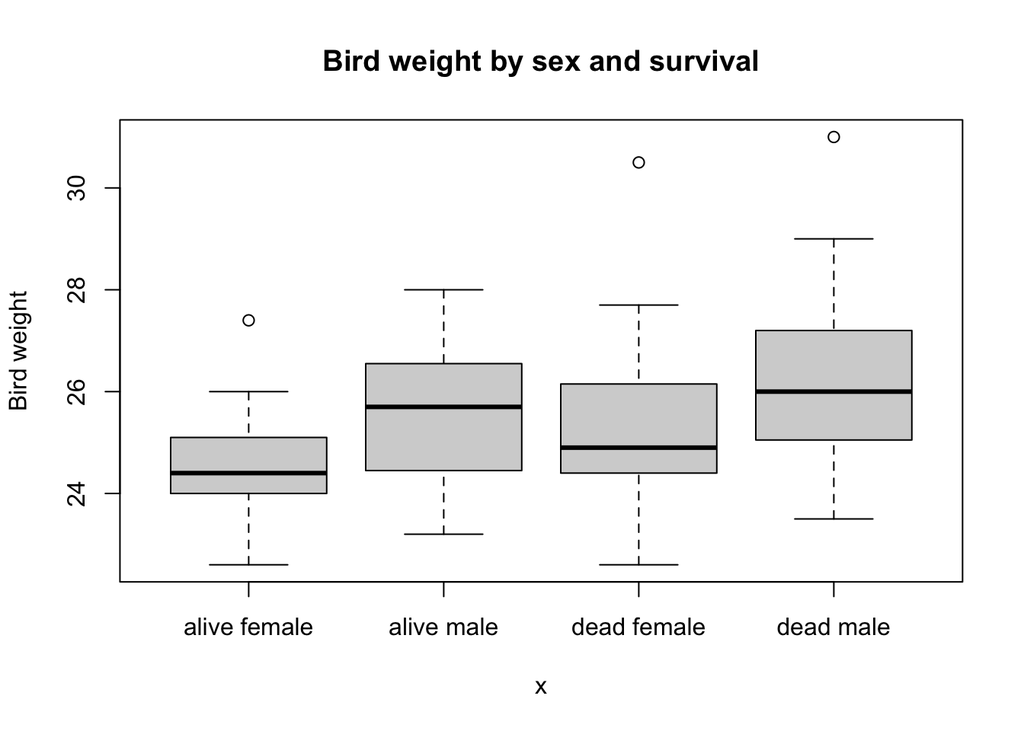

```r
boxplot(y~x, main="Bird weight by sex and survival", ylab="Bird weight")
```

### xlab=

The `xlab=` modifier labels the x-axis

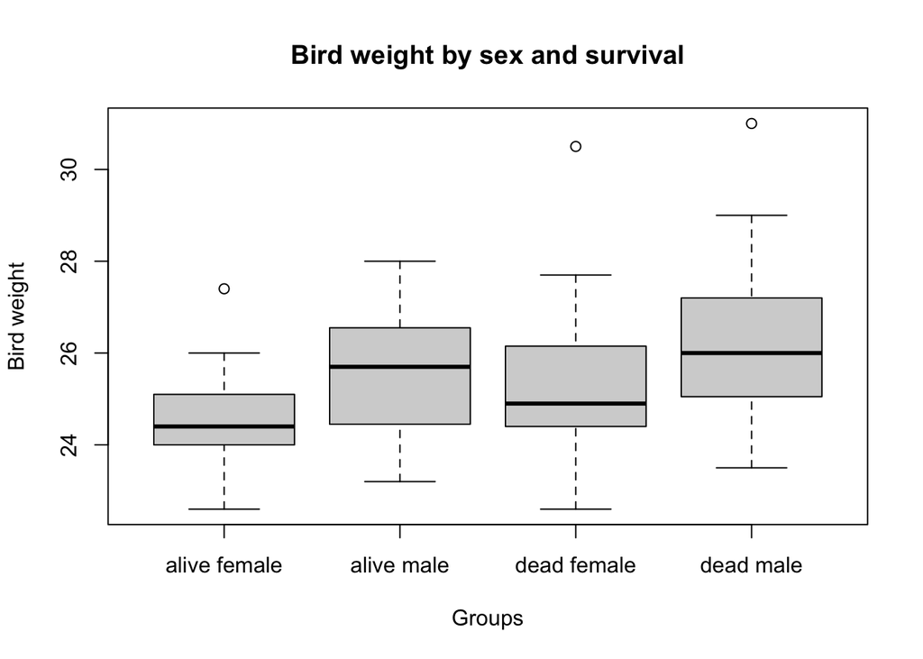

```r
boxplot(y~x, main="Bird weight by sex and survival", ylab="Bird weight", xlab="Groups")
```

### xlim=

The `xlim=` modifier allows you to change the limits of the x-axis

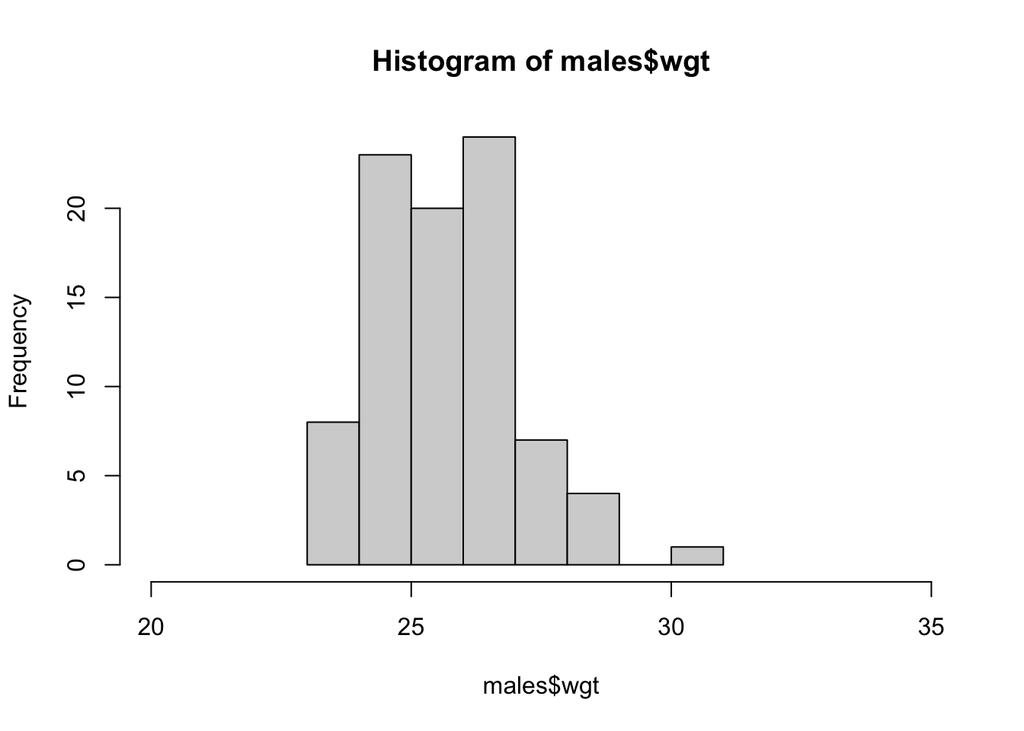

```r
hist(males$wgt, xlim=c(20,35))
```

### ylim=

The `ylim=` modifier allows you to change the limits of the x-axis. Here I increased the y-axis to 40

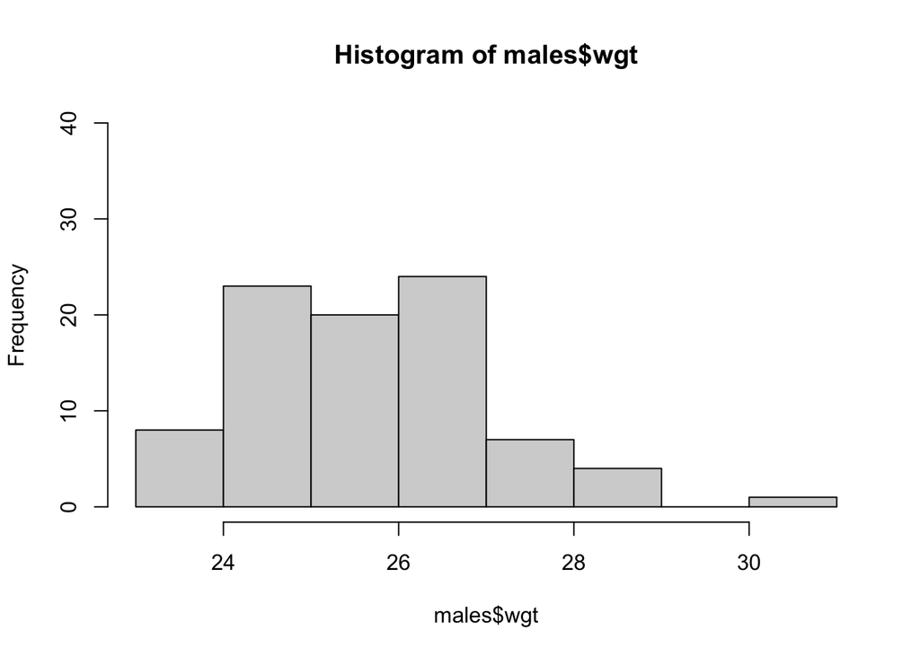

```r
hist(males$wgt, ylim=c(0 ,40))
```

### col=

The `col=` modifier allows you to color the plot. (Arguably, the best function within R)

**Color is a tool!** If you are using multiple colors, don’t just randomly color in boxes, use the color to easily distinguish between groups.

- In my plot the females are pink and the males are blue. Additionally, the alive individuals are a lighter shade and the dead individuals are a darker color.

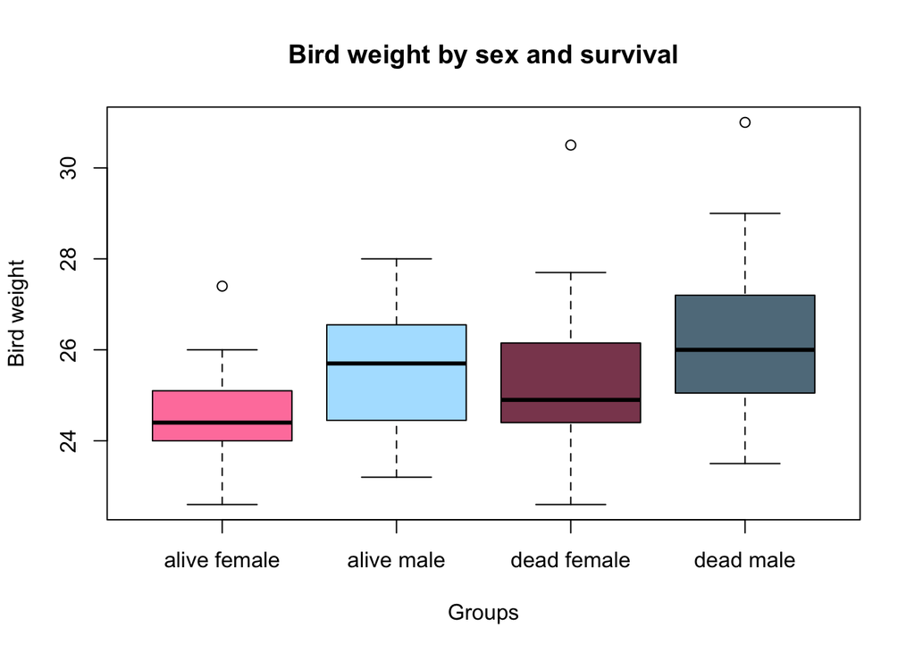

```r
boxplot(y~x, main="Bird weight by sex and survival", ylab="Bird weight", xlab="Groups", col=c("palevioletred1","lightskyblue1", "palevioletred4", "lightskyblue4"))
```

### col=rgb()

`col=rgb()` is more specific than the col= modifier Not to be confused with the notorious RBG, col=rgb() allows you to create custom colors by changing the proportion of red, blue and green in that color.

- For example, looking at the bumpus data for male weight, I can change the color and transparancy of the graph
- The values range from 0 to 1, with 1 being the most extreme and 0 being the least extreme

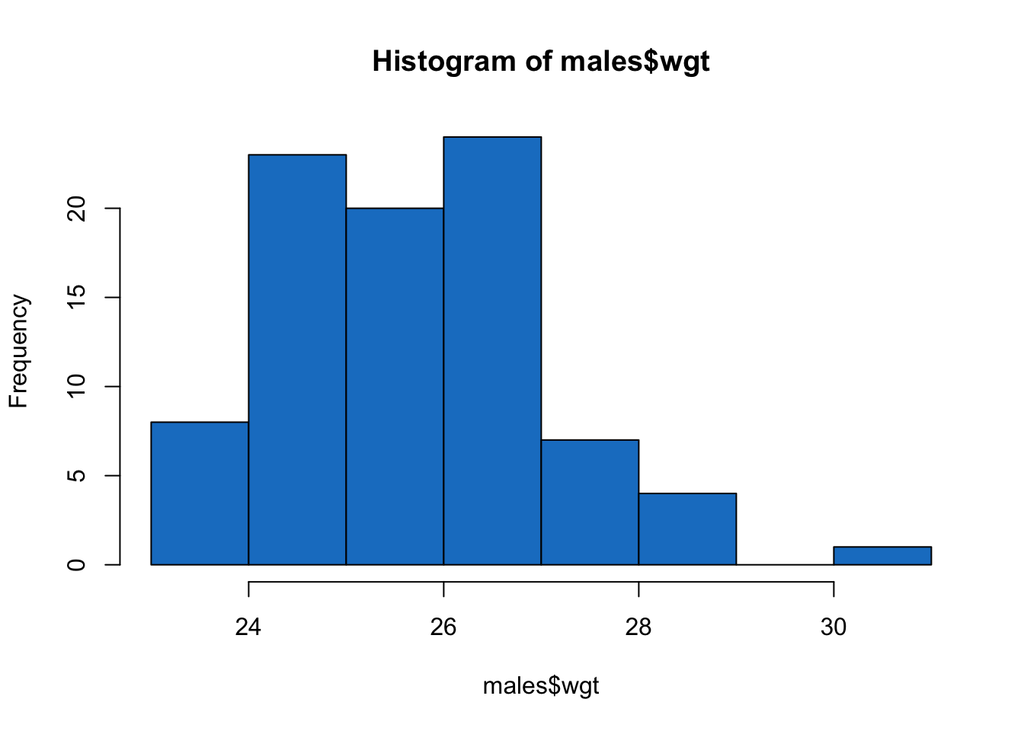

```r
hist(males$wgt, col=rgb(0.1,0.5,0.792,1))
```

### add=TRUE

Using the `add=TRUE` you can combine two histogram code lines into one graph. The add=TRUE is inserted as a modifier into the second hist(). Any modifiers to change graph (ylim, xlim, ylab, xlab, main, etc.) must be added to first histogram function

This is a great way to use the col=rgb() function and change the transparancy of the histograms to see where the histograms overlap. In this example I am using the bumpus dataset to compare male and female bird weight.

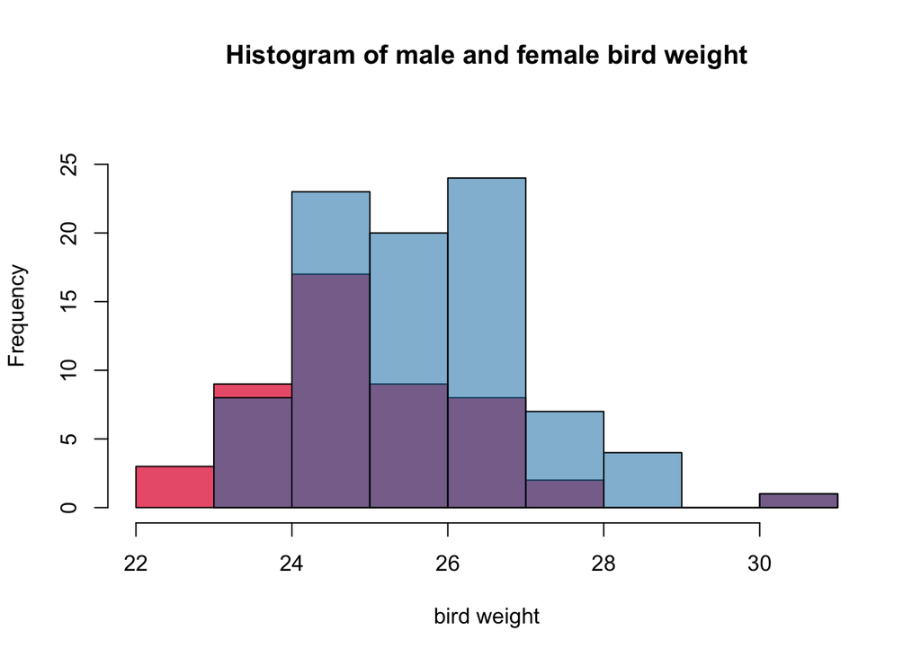

```r
hist(females$wgt, col=rgb(0.9, 0.2, 0.32, 0.8), ylim=c(0,28), xlab=("bird weight"), main=("Histogram of male and female bird weight"))
hist(males$wgt, add=TRUE, col=rgb(0.1, 0.5, 0.7, 0.55))
```

### segments()

The `segments()` modifier is NOT a modifier, so it requires a new line of code to work. The function basically works by connecting two points with a straight line.

- segments(X<sub>1</sub>, Y<sub>1</sub>, X<sub>2</sub>, Y<sub>2</sub>)
- You can change the color of segments using either col=() or col=rbg()
- lwd() changes the thickness of the line

While walking long the mall, I notice there is a single male bird, the exact species that Bumpus used. What a lucky find! I take his mass. I am interested to see if the bird mass is different now from when Bumpus did his experiment **The segment line is the mean masse of the male bird I caught.**

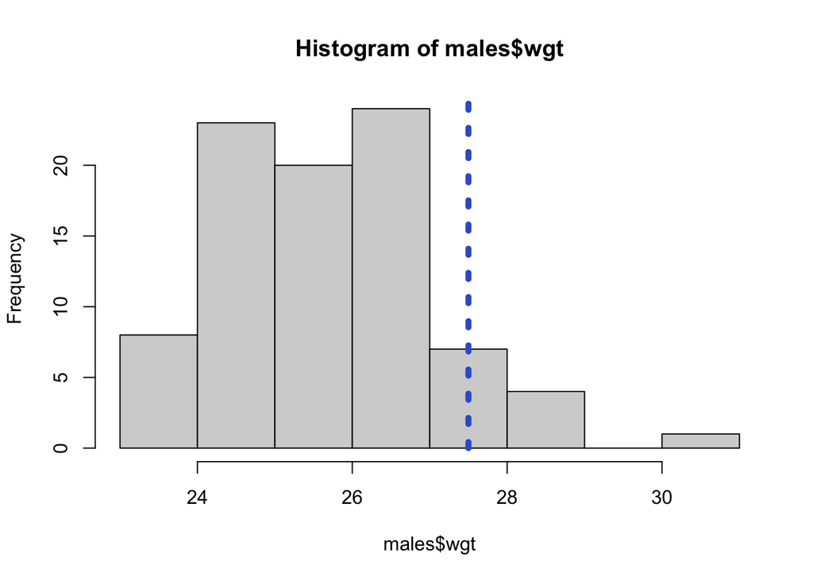

```r
hist(males$wgt)
segments(27.5,0,27.5,25, col="royalblue3", lwd=5, lty="dotted")
```

### text()

`text()` modifier adds text to any plot

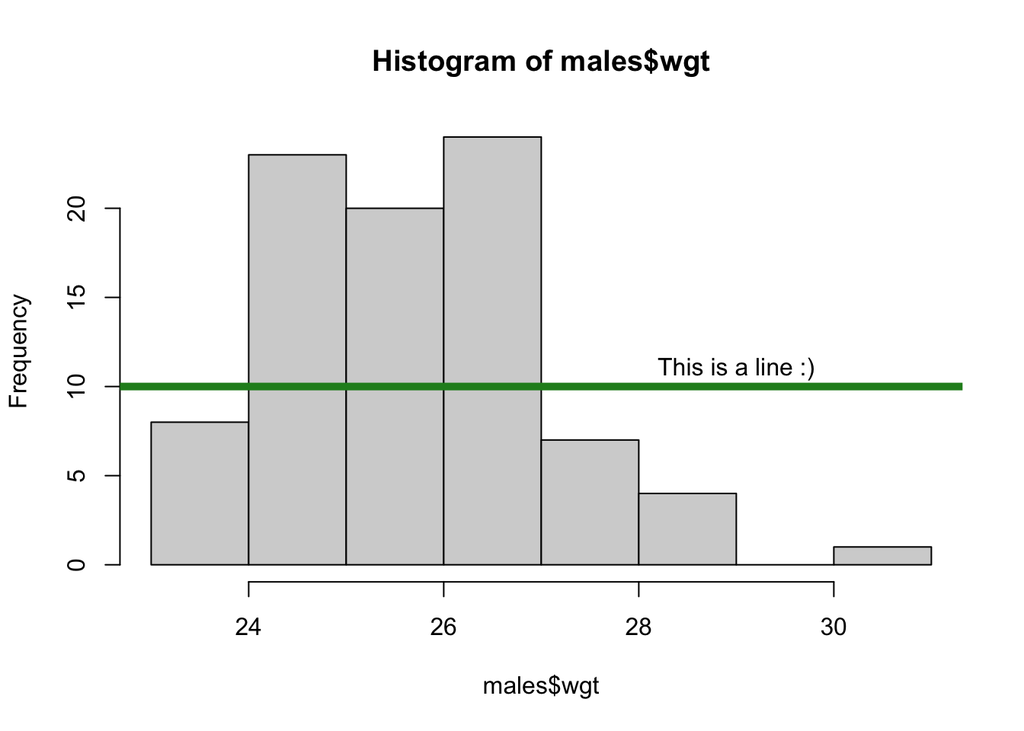

```r
hist(males$wgt)
segments(0,10,40,10, col="forestgreen", lwd=5)
text(29,11,"This is a line :)")
```

### legend()

The `legend()` modifier puts a legend on your graph, telling the reader what colors are certain variables legend(), like segments() needs its own line beneath the histogram

- Continuing with the same graph from above…

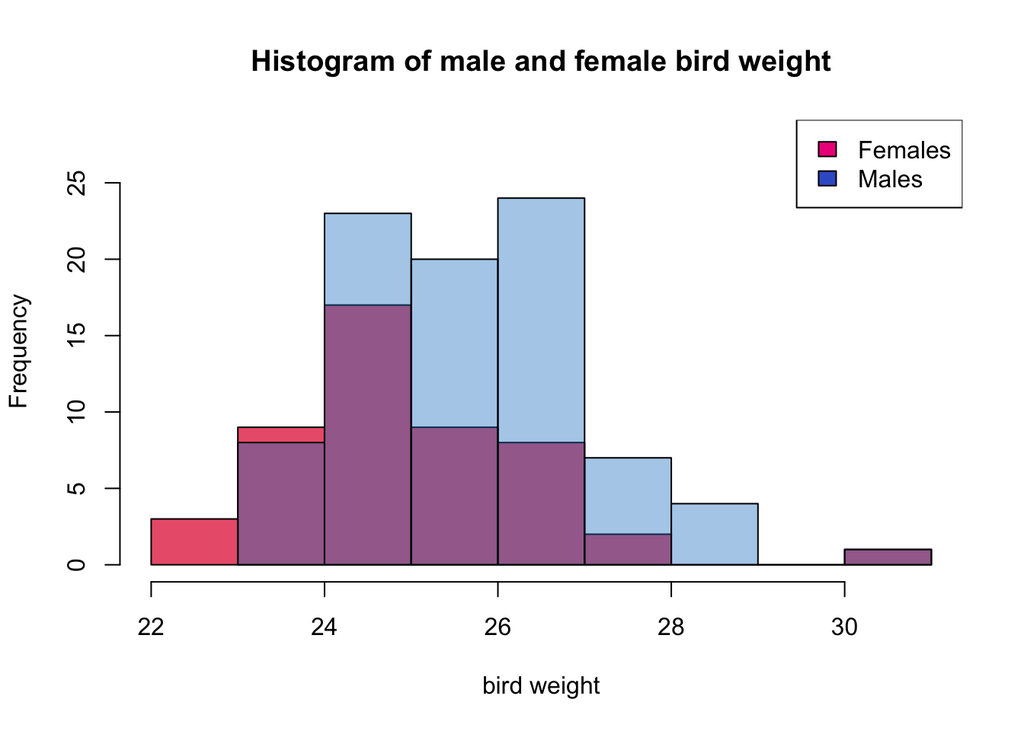

```r
hist(females$wgt, col=rgb(0.9, 0.2, 0.32, 0.8), ylim=c(0,28), xlab=("bird weight"), main=("Histogram of male and female bird weight"))
hist(males$wgt, add=TRUE, col=rgb(0.1, 0.5, 0.792, 0.4))
legend("topright", c("Females", "Males"), fill=c("deeppink2","royalblue3"))
```